# 词序和谐在领属语这里断掉

# 断口跟着家族走，不跟着大陆走

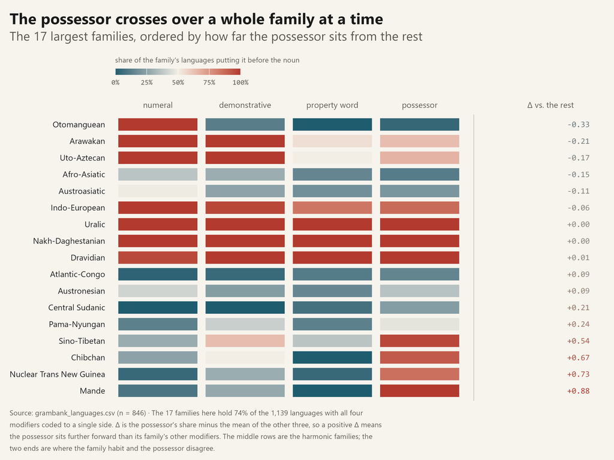

图 4: Each cell is the share of a family’s languages that put that modifier before the noun. Families are ordered by how far the possessor sits from the other three, so the harmonic families land in the middle and the rows where the possessor crosses sit at the two ends.

按家族看，17 个样本够（≥ 10 种语言）的家族覆盖了 74% 的样本量。

**两头那几行才是断口**：Mande 的领属语 100% 前置，其余三个平均只有 12%；Otomanguean 反过来，领属语 4% 前置，其余三个 38%。这种「一个参数整体跑偏」的家族有 4 个朝前偏、1 个朝后偏——不是零散的个体差异，而是成族出现。

大陆层面就粗糙得多：和谐率最高的是 Africa（67%），最低的是 Papunesia（24%）。同一个大陆里坐着相反的阵营：欧亚大陆既有全前置的乌拉尔，也有领属语翻面的汉藏；`Papunesia` 里既有零散分化的南岛，也有成族翻面的跨新几内亚语系。**「哪个洲语序如何」这个问法本身就不成立。**

表 3: 六个地理宏区内部的和谐率（n = 1,139 个四参数齐备的语言）

| 宏区 | 语言数 | 四者同侧占比 |
| --- | --- | --- |
| Africa | 326 | 67% |
| Eurasia | 325 | 57% |
| Australia | 16 | 44% |
| South America | 102 | 30% |
| North America | 108 | 26% |
| Papunesia | 262 | 24% |

表 4: 家族层面的前置比例（按领属语与其余三项的差排序；只列 ≥ 10 种语言的 17 个家族）

| 语系 | 语言数 | 数词 | 指示词 | 属性词 | 领属语 | 领属语−其余 | 四者同侧 |
| --- | --- | --- | --- | --- | --- | --- | --- |
| Mande | 11 | 9% | 27% | 0% | 100% | +0.88 | 0% |
| Nuclear Trans New Guinea | 21 | 5% | 29% | 5% | 86% | +0.73 | 14% |
| Chibchan | 12 | 25% | 50% | 0% | 92% | +0.67 | 8% |
| Sino-Tibetan | 113 | 28% | 64% | 36% | 96% | +0.54 | 25% |
| Pama-Nyungan | 15 | 13% | 40% | 13% | 47% | +0.24 | 40% |
| Central Sudanic | 13 | 0% | 0% | 8% | 23% | +0.21 | 69% |
| Austronesian | 199 | 42% | 23% | 16% | 36% | +0.09 | 27% |
| Atlantic-Congo | 194 | 3% | 5% | 11% | 15% | +0.09 | 70% |
| Dravidian | 27 | 96% | 100% | 100% | 100% | +0.01 | 96% |
| Nakh-Daghestanian | 20 | 100% | 100% | 100% | 100% | +0.00 | 100% |
| Uralic | 26 | 100% | 100% | 100% | 100% | +0.00 | 100% |
| Indo-European | 31 | 100% | 97% | 84% | 87% | -0.06 | 81% |
| Austroasiatic | 59 | 49% | 25% | 19% | 20% | -0.11 | 63% |
| Afro-Asiatic | 52 | 37% | 29% | 15% | 12% | -0.15 | 67% |
| Uto-Aztecan | 18 | 100% | 100% | 50% | 67% | -0.17 | 39% |
| Arawakan | 11 | 100% | 100% | 55% | 64% | -0.21 | 27% |
| Otomanguean | 24 | 100% | 12% | 0% | 4% | -0.33 | 0% |

# 这张报告不能得出的